# ETC 1010 Assignment 2

SOLUTION

1. Describe the steps that you will need to take to read in your electricity usage, and tidy it. Tidy your data, using the `tidyverse` functions. The end product should look something like this:

```
  date       halfhour   kwh
  <date>        <dbl> <dbl>
1 2017-11-24      0.5     0
2 2017-11-24      0.5     0
3 2017-11-24      1       0
4 2017-11-24      1       0
5 2017-11-24      1.5     0
6 2017-11-24      1.5     0
```

although your `halfhour` variable might be more explicit like 12:00-12:30, 12:30-01:00, 01:00-01:30, … And you might want to add week day, month, year variables.

*The steps to cleaning require* - *Reading the data, skipping the first row, setting column namesand with fixed column types.* - *Filtering only rows with id=300* - *Selecting columns related to date and half-hourly kwh* - *Gathering t olong form* - *Making a half-hour variable, as a number* - *Creating several new variables, including week day, month, year, holiday and a date-time. Not all of these are necessary, it depends on the analysis conducted.* - *Subset Jan 1 through Mar 18, 2019.*

2. Subset your data to contain only records for January 1 through March 18, 2019.
3. Aggregate your daily kwh usage. (This really assumes no missing data.) Make a side-by-side boxplot of usage by week day. Are there some days of the week that you typically use more electricity than others?

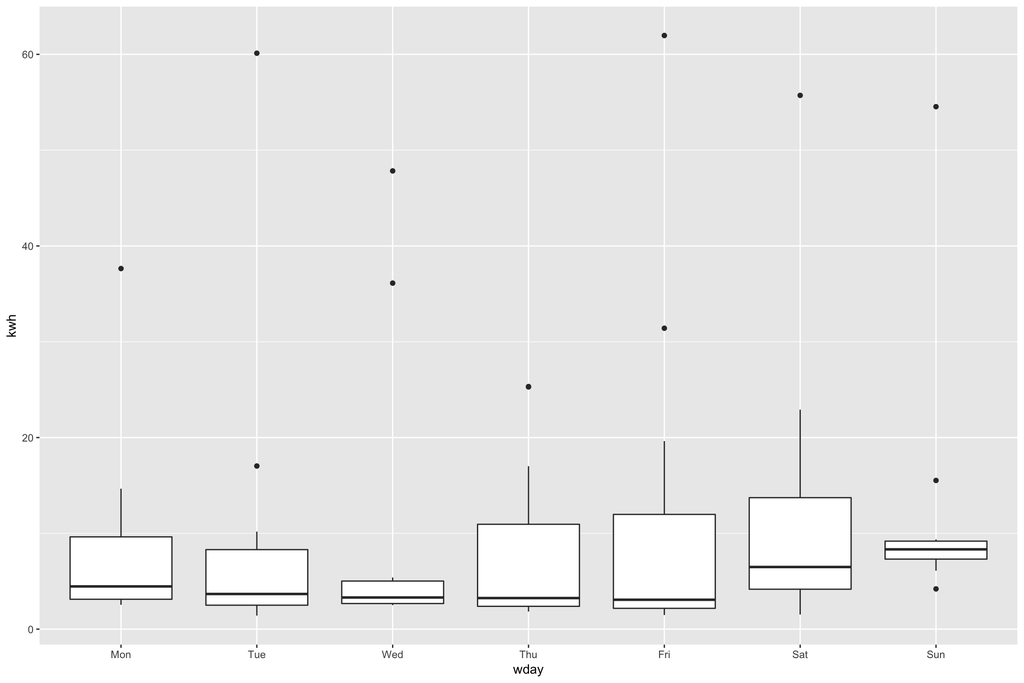

4. Make a line plot of half-hourly usage for the days February 2-7. Describe what you learn about electricity use during this month.

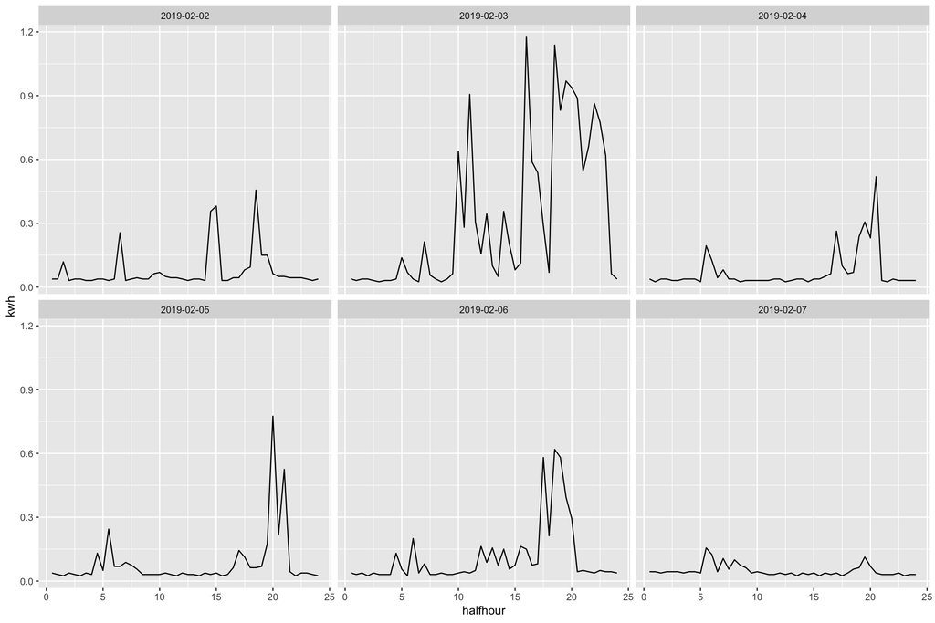

5. Extract temperature data at Melbourne airport from the Bureau of Meterology using the `bomrang` package. Colour the line plots from the previous question, based on the maximum daily temperature. What do you learn about the relationship between your energy use and the maximum daily tempoerature.

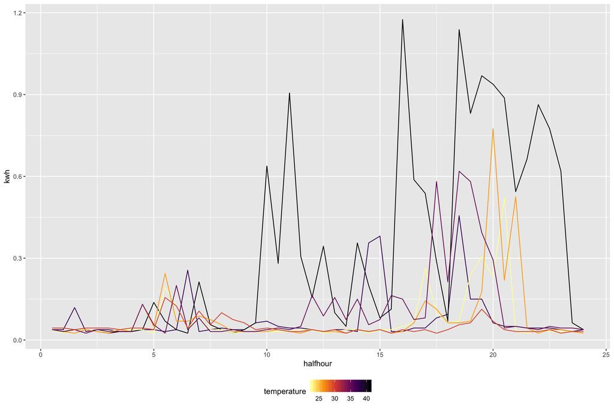

6. Decide on one more plot, for each group member, to make to learn about your energy usage and weather. Make these plots and write some paragraphs describing what you have learned.
7. Build your answers to these questions into a learnr interactive tutorial, with separate pages as appropriate for each question (2-6), and an interactive quiz on each page relating to the material on the page, to help the reader engage in your energy data analysis.